# Session 6

Ecological Data Collection and Processing: Exercises

Ward Fonteyn & Stef Haesen

02/12/2021

# Session 6: Ordination

## Ordination

- Multivariate analysis
- Detect patterns
- Emphasis on continuity in the data

Goal: reduce dimensions

## Ordination methods

- PCA: Principal component analysis
- PCoA: Principal coordinate analysis
- NMDS: Non-metric multidimensional scaling

## Datasets

- varespec: cover values of 44 psecies in 24 plots in lichen pastures
- varechem: soil characteristics for the same plots

## Exercises

**PCA**

- Perform a PCA on the environmental data and plot the results.
- Extract the eigen values and calculate the amount of variation explained by each axis.

**PCoA**

- Repeat the same tasks with the PCoA.

**NMDS**

- Perform a NMDS on the species data. Which dissimilarity index should be used?
- Try to plot the results and add the environmental variables to the plot.

## Part 1

```r
# First update package
library(edcpR)
data(varespec_s6, package = "edcpR")
data(varechem_s6, package = "edcpR")
```

**PCA**

- Perform a PCA on the environmental data and plot the results.
  - **TIP**: vegan package
- Extract the eigen values and calculate the amount of variation explained by each axis.

## Loading data

```r
data(varespec_s6, package = "edcpR")
data(varechem_s6, package = "edcpR")
sp <- varespec_s6
env <- varechem_s6
str(env[,10:17])
```

```
## 'data.frame':    24 obs. of  8 variables:
##  $ Mn            : num  58.1 52.4 32.1 132 50.1 ...
##  $ Zn            : num  4.5 5.4 16.8 10.7 6.6 9.1 7.4 5.2 9.3 9.1 ...
##  $ Mo            : num  0.3 0.3 0.8 0.2 0.3 0.4 0.3 0.3 0.3 0.5 ...
##  $ Baresoil      : num  43.9 23.6 21.2 18.7 46 40.5 23 29.8 17.6 29.9 ...
##  $ Humdepth      : num  2.2 2.2 2 2.9 3 3.8 2.8 2 3 2.2 ...
##  $ pH            : num  2.7 2.8 3 2.8 2.7 2.7 2.8 2.8 2.8 2.8 ...
##  $ Managementtype: int  1 2 1 1 3 3 3 3 3 2 ...
##  $ Use           : chr  "Haypastu" "Haypastu" "Haypastu" "Haypastu" ...
```

```r
env$Managementtype <- as.factor(env$Managementtype)
env$Use <- as.factor(env$Use)
```

## PCA (1)

```r
# rda without conditions or constraints is PCA
# We have nutrient contents (g/kg), soil depth (cm), pH (1-14)...
# scale = TRUE for data on different scales!!
PCA <- rda(env[,1:10], scale=TRUE)
```

## PCA (2)

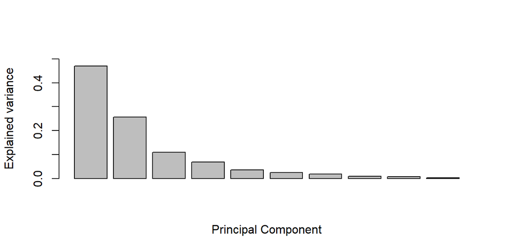

```r
# Bar plot of relative eigen values (= percentage variance explained by each axis)
eig <- as.vector(PCA$CA$eig)
barplot(eig/sum(eig), xlab = "Principal Component",
          ylab = "Explained variance", ylim = c(0, 0.5))
```

## PCA (3)

```r
# Calculate the percent of variance explained by first two or three axes
# First two axes explain 73% of the variance
# First three axes explain 83% of the variance
sum((eig/sum(eig))[1:2])
```

```
## [1] 0.7255994
```

```r
sum((eig/sum(eig))[1:3])
```

```
## [1] 0.8343673
```

```r
# Three dimensional representation is possible, but more difficult
# We prefer to plot in two dimensions
# Solution: plot PC1 Vs. PC2 & PC1 vs. PC3
```

## PCA (4)

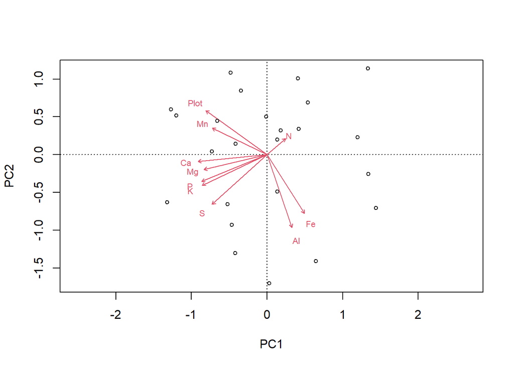

```r
# In a biplot of a PCA, environment's scores are drawn as arrows
# These arrows point in direction of increasing value for that variable
biplot(PCA, choices=c(1,2), type=c("text","points"))
```

## PCA (5)

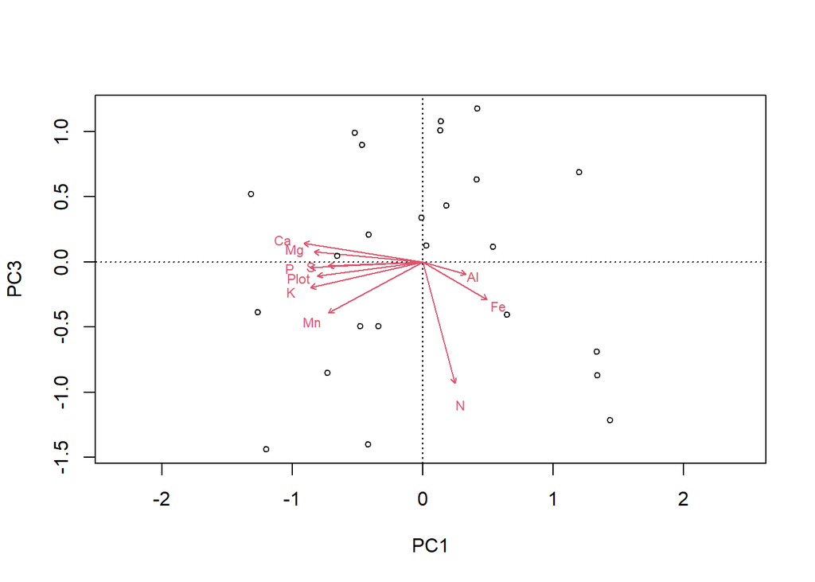

```r
# If we would like to include three dimensions: biplot of axis 1 vs 3
biplot(PCA, choices=c(1,3), type=c("text","points"))
```

## Part 2

**PCoA**

- Repeat the same tasks with the PCoA
  - **TIP**: ape package
  - **TIP**: gowdis() function from FD package

## PCoA (1)

```r
# First step: create a distance matrix
# We have quantitative and categorical environmental variables
# We thus use Gower distance for mixed variables
dist <- gowdis(env)
```

## PCoA (2)

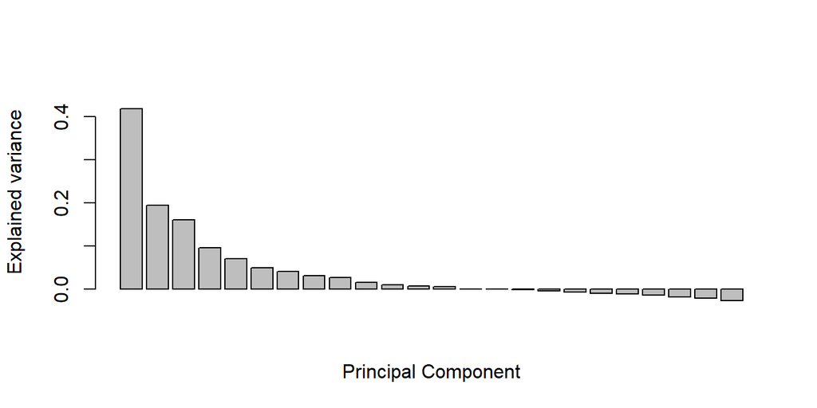

```r
# Perform PCoA & plot the eigenvalues
PCoA <- pcoa(dist)
barplot(PCoA$values$Relative_eig, xlab = "Principal Component",
          ylab = "Explained variance", ylim = c(0, 0.45))
```

## PCoA (3)

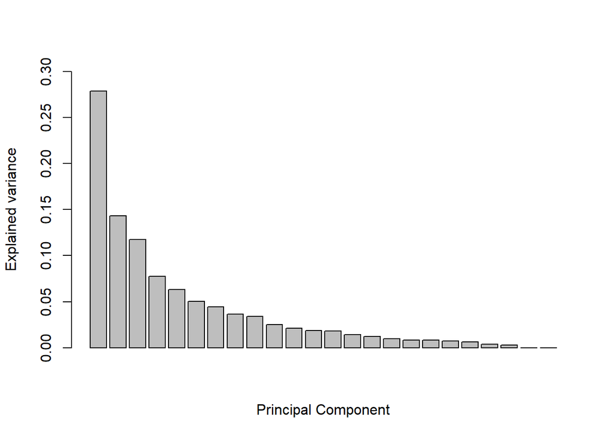

```r
# Some distance measures may result in negative eigenvalues --> add a correction
PCoA <- pcoa(dist, correction = "cailliez")
barplot(PCoA$values$Rel_corr_eig, xlab = "Principal Component",
          ylab = "Explained variance", ylim = c(0, 0.3))
```

## PCoA (4)

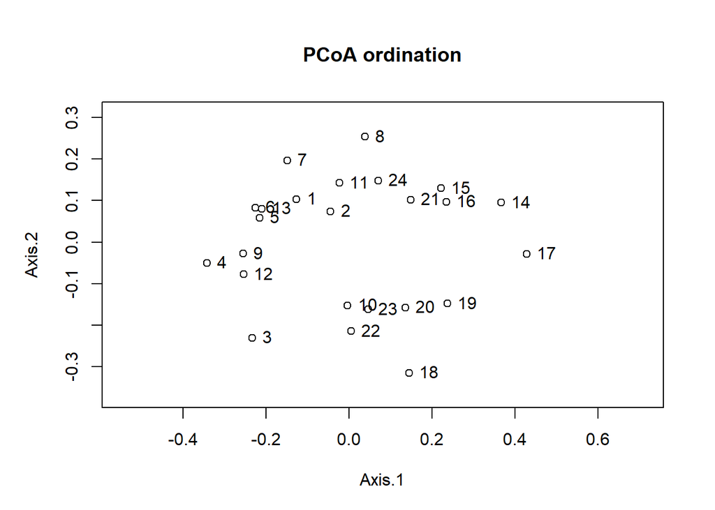

```r
# There are no variables plotted on this biplot (input = dissimilarity matrix)
biplot.pcoa(PCoA)
```

## PCoA (5)

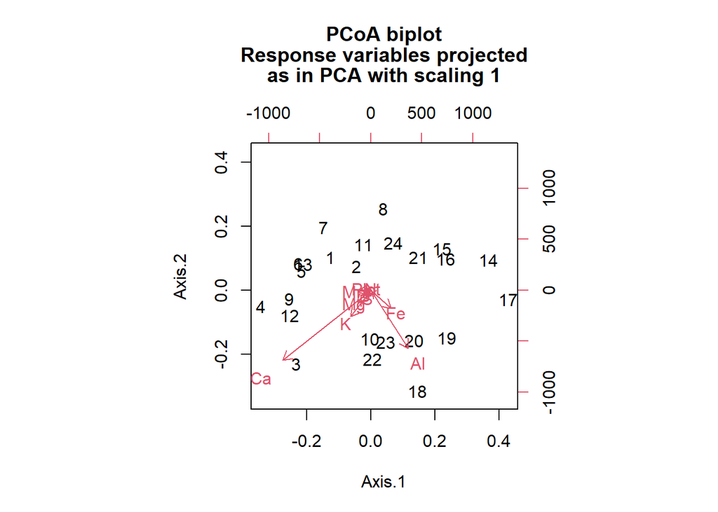

```r
# However, we could work around this problem
biplot.pcoa(PCoA, env[1:10])
```

## Part 3

**NMDS**

- Perform a NMDS on the species data. Which dissimilarity index should be used?
  - **TIP**: metaMDS function from vegan package
- Try to plot the results and add the environmental vairables to the plot
  - **TIP**: envfit function from vegan package

## NMDS (1)

```r
# Determine the number of dimensions for the final NMDS
# Run NMDS for 1 up to 10 dimensions
# Bray-Curtis distance matrix for species matrix with cover data
# If you don`t provide a dissimilarity matrix, metaMDS automatically applies Bray-Curtis
A<-vector()
B<-vector()
for (i in 1:10) {
  NDMS <- metaMDS(sp, distance = "bray", k=i, autotransform = FALSE, trymax=100)
  solution <- NDMS$converged
  stress <- NDMS$stress
  A1 <- cbind(solution,stress)
  B <- rbind(B,i)
  A <- rbind(A,A1)
}
```

```
## *** No convergence -- monoMDS stopping criteria:
##    100: scale factor of the gradient < sfgrmin
## *** Solution reached
## *** Solution reached
## *** Solution reached
## *** Solution reached
## *** Solution reached
## *** Solution reached
## *** No convergence -- monoMDS stopping criteria:
##    100: no. of iterations >= maxit
## *** No convergence -- monoMDS stopping criteria:
##    100: no. of iterations >= maxit
## *** No convergence -- monoMDS stopping criteria:
##    100: no. of iterations >= maxit
```

## NMDS (2)

```r
#Combine results of all NMDS
NMDSoutput<-data.frame(B,A)
names(NMDSoutput) <- c("k","Solution?","Stress")
NMDSoutput
```

```
##      k Solution?      Stress
## i    1         0 0.298508636
## i.1  2         1 0.088925053
## i.2  3         1 0.062331738
## i.3  4         1 0.046712528
## i.4  5         1 0.035207025
## i.5  6         1 0.027903505
## i.6  7         1 0.021643175
## i.7  8         0 0.016151602
## i.8  9         0 0.011766320
## i.9 10         0 0.007786146
```

## NMDS (3)

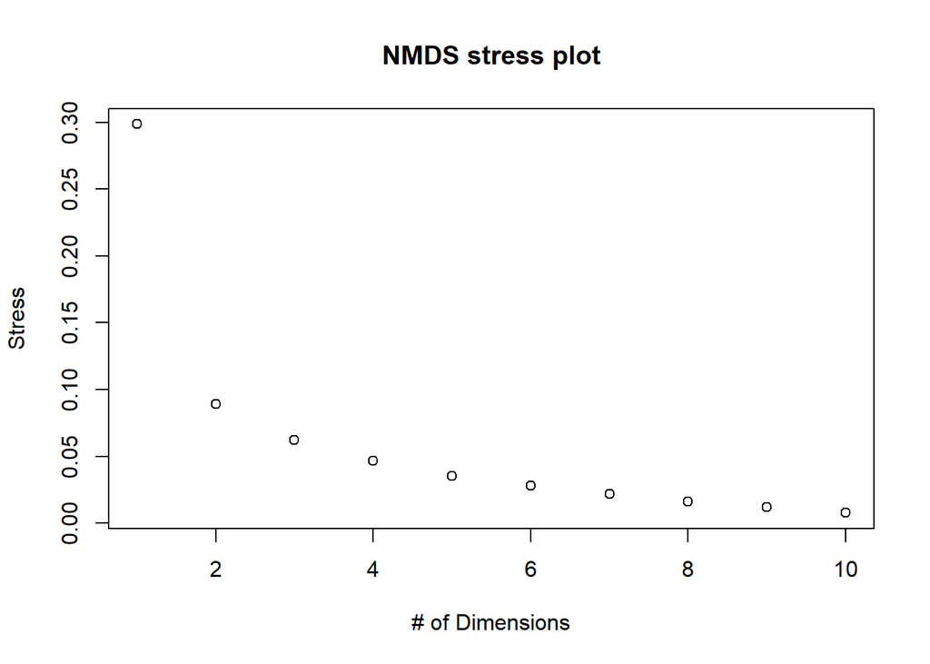

## NMDS (4)

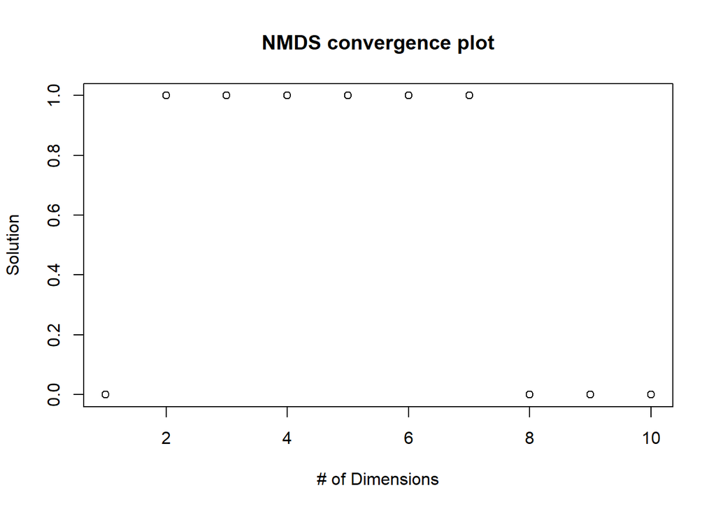

## NMDS (5)

```r
# Final result depends on the initial random placement of the points
# We need set a seed to make the results reproducible
set.seed(999)
NMDSfinal <- metaMDS(sp, distance = "bray", k=2, autotransform = FALSE, trymax=100 )
```

```
## *** Solution reached
```

## NMDS (6)

```r
# We can again check the stress
NMDSfinal$stress
```

```
## [1] 0.08892505
```

## NMDS (7)

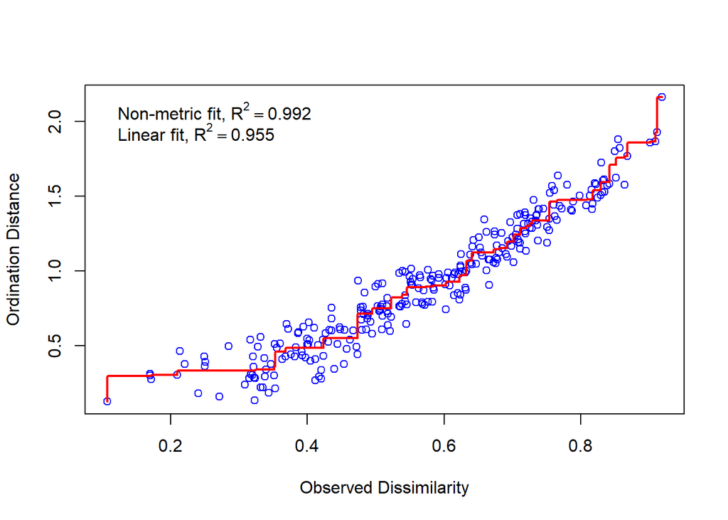

```r
# Let’s check the results of NMDSfinal with a stressplot
stressplot(NMDSfinal)
```

## NMDS (8)

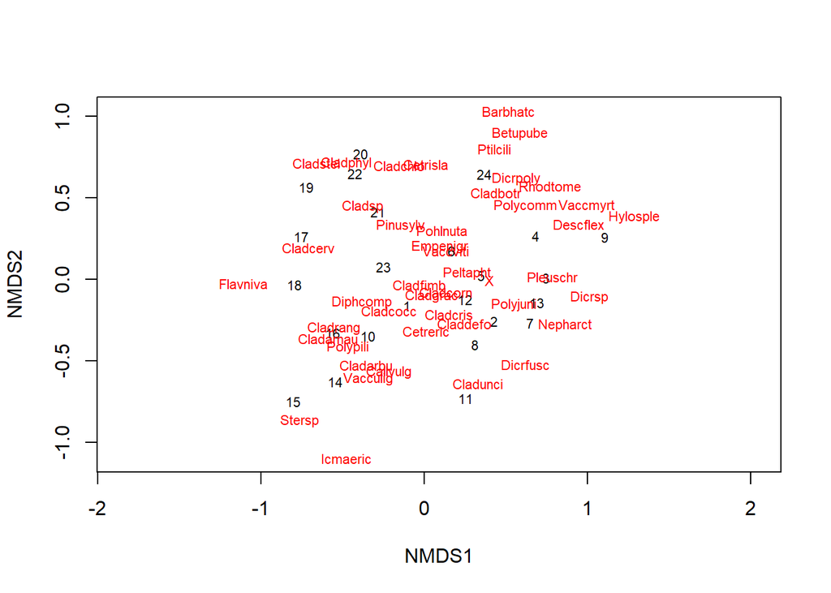

```r
#Plot results wit text for species
plot(NMDSfinal, type = "t")
```

## NMDS (9)

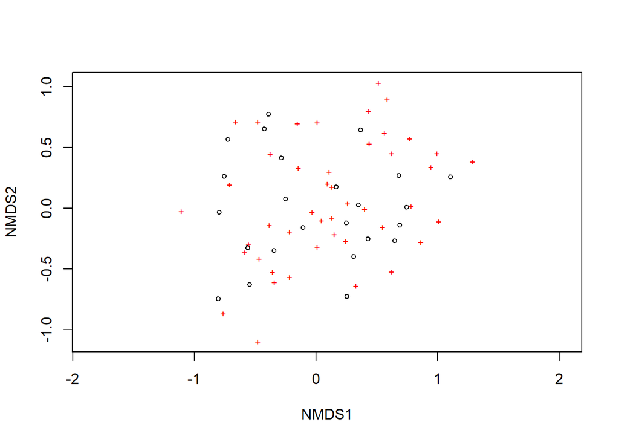

```r
#Plot results wit points for species
plot(NMDSfinal, type = "p")
```

## NMDS (10)

```r
# There are no environmental variables on the plot (same as PCoA)
# We can again work around this
ef <- envfit(NMDSfinal, env[1:10], permu = 999)
```

## NMDS (11)

```
##
## ***VECTORS
##
##         NMDS1    NMDS2     r2 Pr(>r)
## Plot  0.99756  0.06979 0.9062  0.001 ***
## N    -0.00942 -0.99996 0.1977  0.113
## P     0.60696  0.79474 0.2883  0.026 *
## K     0.84093  0.54115 0.1869  0.107
## Ca    0.82578  0.56399 0.3608  0.012 *
## Mg    0.85227  0.52310 0.3039  0.021 *
## S     0.37828  0.92569 0.1036  0.314
## Al   -0.98296  0.18382 0.5278  0.001 ***
## Fe   -0.98389  0.17878 0.4539  0.001 ***
## Mn    0.99053  0.13727 0.4253  0.005 **
## ---
## Signif. codes:  0 '***' 0.001 '**' 0.01 '*' 0.05 '.' 0.1 ' ' 1
## Permutation: free
## Number of permutations: 999
```

## NMDS (12)

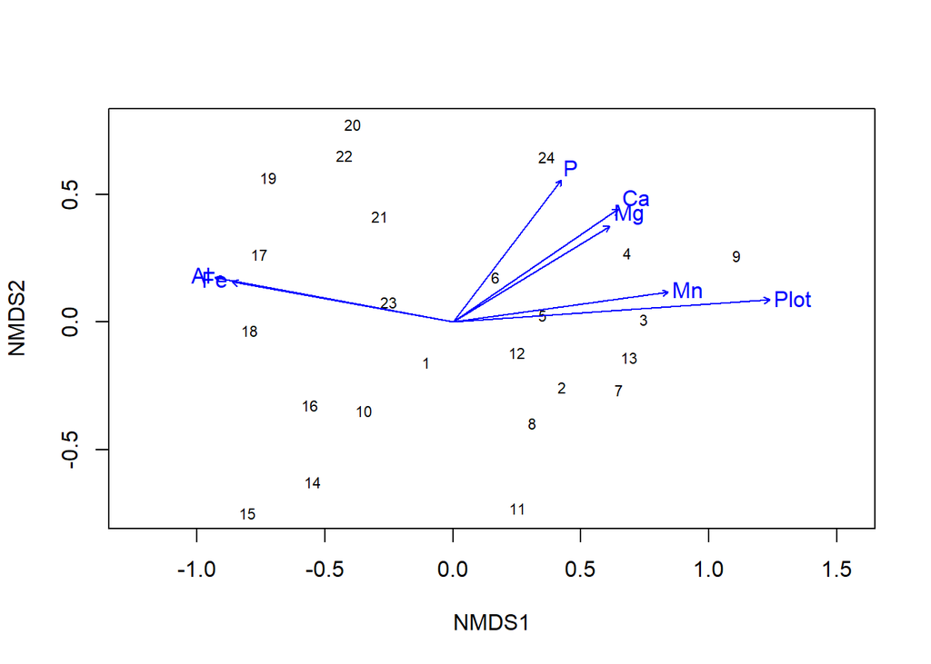

```r
# Plot the vectors of the significant correlations
plot(NMDSfinal, type = "t", display = "sites")
plot(ef, p.max = 0.05)
```

## Assignment

There is NO assignment for this week’s session:

- Combined assigned for the session on ordination and classification
- Online after the session on classification (December 9th)